# Analisis Antofagasta

Diego Calbucheo

Horacio Samaniego

## Objetivos:

*Cargamos las librerías*:

Carga del archivo con los datos

```r
#setwd("./")
load("workspace_antofa.RData")
# antofa<-st_read("antofa.shp") # provided in th e.RData file
antofa<-antofa%>%
  st_transform(32719)
```

## ANOVA NDVI~ISMT

1. Cuartilización del entorno socioeconómico

   Se establecieron 4 clases de niveles socioeconómicos a partir del calculo de los cuartiles de la distribución de valores del Indice Socio-Material de Hogares. Este cálculo se hizo a partir de la distribución completa de individuos para los que es posible imputar una antena de residencia.
2. En base al ISMT de cada zona censal donde está el parque

```r
a1<-antofa |>
  mutate(Q=cut(ismt, breaks=c(0, 0.166461, 0.527227, 0.630018, 1), labels=c("Q1","Q2","Q3","Q4"))) |>
  select(mean_ndvi, ismt, Q) |>
  distinct() |>
  st_drop_geometry()

#st_geometry(a1) <- NULL
```

## 1.1 Histogramas

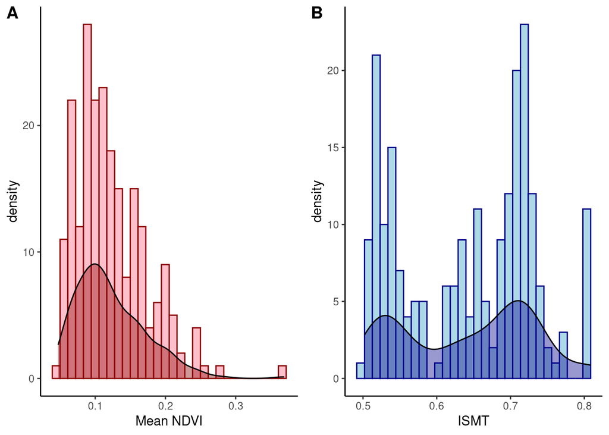

```r
# hist(a1$ismt)
# hist(a1$mean_ndvi)

h_ismt <- ggplot(a1,aes(x = ismt)) +
  geom_histogram(color="darkblue", fill="lightblue", position="dodge") +
  geom_density(alpha = .4,fill = "darkblue") +
  xlab("ISMT") +
  theme_classic()

h_ndvi <- ggplot(a1,aes(x = mean_ndvi)) +
  geom_histogram(color="darkred", fill="pink", position="dodge") +
  geom_density(alpha = .4,fill = "darkred") +
  xlab("Mean NDVI") +
  theme_classic()
#
# print(h_ndvi)
# print(h_ismt)

ggarrange(h_ndvi, h_ismt,labels = c("A", "B"), ncol = 2)
```

```r
ggsave("histogramas_ndvi+ismt.pdf",width=12,height=5, units = "cm")
ggsave("histogramas_ndvi+ismt.png",width=12,height=5, units = "cm")
```

## 2. Modelo estadístico, ANOVA y visualización de los datos

2.1. Modelo estadístico

Aqui buscamos evaluar el efecto del quartil de grupo socioeconomómico en que se emplaza cada AVU respecto de su verdor medido por el valor medio de NDVI.

```r
m1 <- lm(mean_ndvi ~ Q, a1)
```

Diagnósticos. Evaluamos los supuestos asociados a la ANOVA.

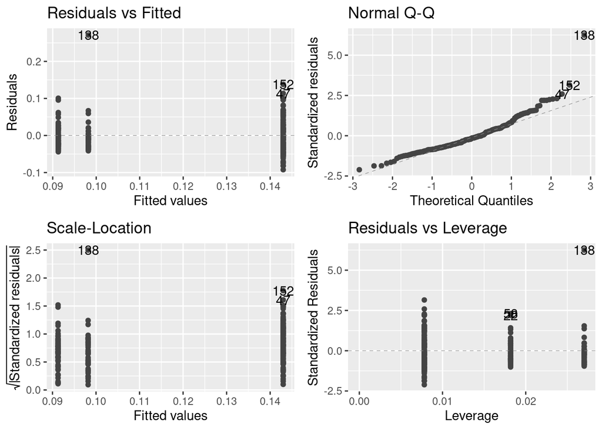

```r
autoplot(m1, smooth.colour = NA) #normalidad Y CONSTANCIA de la varianza, ok
```

## ANOVA

```r
anova(m1)
```

```
## Analysis of Variance Table
##
## Response: mean_ndvi
##            Df  Sum Sq  Mean Sq F value    Pr(>F)
## Q           2 0.12925 0.064626  33.433 2.203e-13 ***
## Residuals 217 0.41946 0.001933
## ---
## Signif. codes:  0 '***' 0.001 '**' 0.01 '*' 0.05 '.' 0.1 ' ' 1
```

F-value = varianza (Mean SqQ) / error de la varianza (Mean Sq Residuals) F-value = 0.064626 / 0.001933 = 33.433 ¿Qué significa que F-value sea 33.433?

Evaluamo la validez del análisis comparándolo con el valor crítico.

```r
qf(0.95, 2, 217) # 95% - Df (Q) - Df (Residuals)
```

```
## [1] 3.037472
```

[output not shown]

Por otro lado, ya que el *p-value* < 0.05, también podemos rechazar la H0

Entonces: a. F-value >> qf(0.95, 2, 217) –> se rechaza H0 b. p-value < 0.95 –> se rechaza H0 c. Esto demuestra que, al menos, una de las medias es diferente de las otras!

## 2.3. `Summary` nos permite evaluar el efecto de cada factor predictor - Q

```r
summary(m1)
```

```
##
## Call:
## lm(formula = mean_ndvi ~ Q, data = a1)
##
## Residuals:
##       Min        1Q    Median        3Q       Max
## -0.092394 -0.029463 -0.006832  0.019705  0.271038
##
## Coefficients:
##              Estimate Std. Error t value Pr(>|t|)
## (Intercept)  0.098187   0.007228  13.584  < 2e-16 ***
## QQ3         -0.006907   0.009348  -0.739    0.461
## QQ4          0.044810   0.008206   5.460  1.3e-07 ***
## ---
## Signif. codes:  0 '***' 0.001 '**' 0.01 '*' 0.05 '.' 0.1 ' ' 1
##
## Residual standard error: 0.04397 on 217 degrees of freedom
## Multiple R-squared:  0.2356, Adjusted R-squared:  0.2285
## F-statistic: 33.43 on 2 and 217 DF,  p-value: 2.203e-13
```

La columna Estimate nos indica que

1. Q2 tiene una media de 0.098187
2. La variación de la media de Q3 es casi nula respecto a la de Q2, solo 0.006907
3. La media que más difiere es la de Q4, 0.098187 + 0.044810 = 0.142997

## 2.4 Tukey

Este test nos permite evaluar cuál de los pares cuartiles difiere mas.

```r
m2<-aov(mean_ndvi~Q, a1)
TukeyHSD(m2)
```

```
##   Tukey multiple comparisons of means
##     95% family-wise confidence level
##
## Fit: aov(formula = mean_ndvi ~ Q, data = a1)
##
## $Q
##               diff         lwr        upr     p adj
## Q3-Q2 -0.006906769 -0.02896767 0.01515413 0.7406742
## Q4-Q2  0.044809563  0.02544322 0.06417591 0.0000004
## Q4-Q3  0.051716333  0.03498807 0.06844459 0.0000000
```

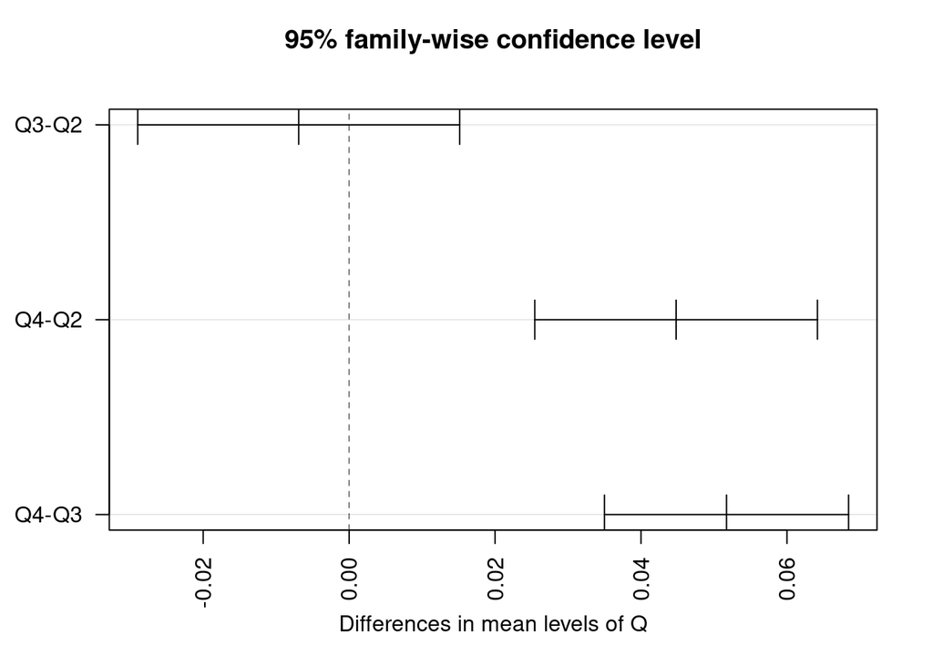

```r
tk<-TukeyHSD(m2)
plot(tk, las=2)
```

Test Tukey nos dice que

- La mayor diferencia es entre Q4 y Q3 (diff = 0.05171)

## 2.5. Ploteamos

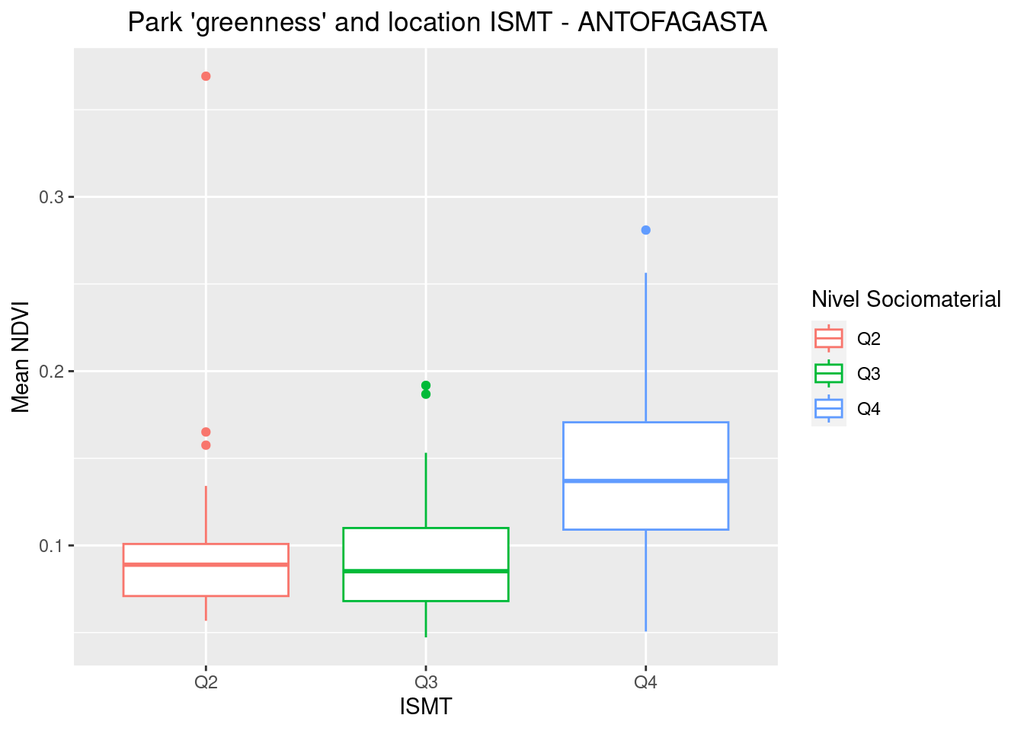

```r
ggplot(a1, aes(x=Q, y=mean_ndvi, colour=Q))+
 geom_boxplot()+
  ylab("Mean NDVI")+
  labs(title = NULL)+
  xlab("ISMT")+
    labs(color="Nivel Sociomaterial")+
ggtitle("       Park 'greenness' and location ISMT - ANTOFAGASTA")
```

```r
## Al final, este no es tan informativo!
# ggplot(a1, aes(x=Q, y=mean_ndvi, colour=Q))+
#   geom_violin()+
#   ylab("Mean NDVI")+
#   labs(title = NULL)+
#   xlab("Nivel Sociomaterial Territorial)")+
#     labs(color="Nivel Sociomaterial")+
# ggtitle("'Verdor' de los parques y nivel sociomaterial
#        de su entorno - ANTOFAGASTA")
```

# Evaluación por hora (línea de tiempo)

## 3. Categorización para la línea de tiempo

## 3.1 Categorización del VERDOR (Bajo, medio y alto)

```r
TercilesNDVI <- function(x) {
  cut(x, breaks=c(quantile(antofa$mean_ndvi, probs = seq(0, 1, 1/3))),
      labels=c("Verdor bajo","Verdor medio","Verdor alto"), include.lowest=TRUE)
}

antofa$Verdor=sapply(antofa$mean_ndvi, TercilesNDVI)
```

## 3.2 Entropía (H) media por hora (verdor)

```r
# t1<-antofa%>%
#   group_by(hour, Verdor) |>
#   summarise(mean_H = mean(H))
kableExtra::kable(t1) |>
  kableExtra::kable_styling(latex_options = "striped")
```

| hour | Verdor | mean_H | geometry |
| --- | --- | --- | --- |
| 0 | Verdor bajo | 1.820461 | MULTIPOLYGON (((356357.8 73… |
| 0 | Verdor medio | 1.688299 | MULTIPOLYGON (((354114.4 73… |
| 0 | Verdor alto | 1.772919 | MULTIPOLYGON (((353649.5 73… |
| 1 | Verdor bajo | 1.770645 | MULTIPOLYGON (((356357.8 73… |
| 1 | Verdor medio | 1.631137 | MULTIPOLYGON (((354114.4 73… |
| 1 | Verdor alto | 1.721605 | MULTIPOLYGON (((353649.5 73… |
| 2 | Verdor bajo | 1.707752 | MULTIPOLYGON (((356357.8 73… |
| 2 | Verdor medio | 1.570821 | MULTIPOLYGON (((354114.4 73… |
| 2 | Verdor alto | 1.675854 | MULTIPOLYGON (((353649.5 73… |
| 3 | Verdor bajo | 1.652646 | MULTIPOLYGON (((356357.8 73… |
| 3 | Verdor medio | 1.512287 | MULTIPOLYGON (((354114.4 73… |
| 3 | Verdor alto | 1.627848 | MULTIPOLYGON (((353649.5 73… |
| 4 | Verdor bajo | 1.592701 | MULTIPOLYGON (((356357.8 73… |
| 4 | Verdor medio | 1.464337 | MULTIPOLYGON (((354114.4 73… |
| 4 | Verdor alto | 1.590221 | MULTIPOLYGON (((353649.5 73… |
| 5 | Verdor bajo | 1.552623 | MULTIPOLYGON (((356357.8 73… |
| 5 | Verdor medio | 1.424395 | MULTIPOLYGON (((354114.4 73… |
| 5 | Verdor alto | 1.550694 | MULTIPOLYGON (((353649.5 73… |
| 6 | Verdor bajo | 1.529606 | MULTIPOLYGON (((356357.8 73… |
| 6 | Verdor medio | 1.393118 | MULTIPOLYGON (((354114.4 73… |
| 6 | Verdor alto | 1.521067 | MULTIPOLYGON (((353649.5 73… |
| 7 | Verdor bajo | 1.530402 | MULTIPOLYGON (((356357.8 73… |
| 7 | Verdor medio | 1.402733 | MULTIPOLYGON (((354114.4 73… |
| 7 | Verdor alto | 1.529481 | MULTIPOLYGON (((353649.5 73… |
| 8 | Verdor bajo | 1.444281 | MULTIPOLYGON (((356357.8 73… |
| 8 | Verdor medio | 1.304116 | MULTIPOLYGON (((354114.4 73… |
| 8 | Verdor alto | 1.415907 | MULTIPOLYGON (((353649.5 73… |
| 9 | Verdor bajo | 1.505630 | MULTIPOLYGON (((356357.8 73… |
| 9 | Verdor medio | 1.377363 | MULTIPOLYGON (((354114.4 73… |
| 9 | Verdor alto | 1.491589 | MULTIPOLYGON (((353649.5 73… |
| 10 | Verdor bajo | 1.703640 | MULTIPOLYGON (((356357.8 73… |
| 10 | Verdor medio | 1.600134 | MULTIPOLYGON (((354114.4 73… |
| 10 | Verdor alto | 1.703062 | MULTIPOLYGON (((353649.5 73… |
| 11 | Verdor bajo | 1.821745 | MULTIPOLYGON (((356357.8 73… |
| 11 | Verdor medio | 1.759263 | MULTIPOLYGON (((354114.4 73… |
| 11 | Verdor alto | 1.870365 | MULTIPOLYGON (((353649.5 73… |
| 12 | Verdor bajo | 1.883606 | MULTIPOLYGON (((356357.8 73… |
| 12 | Verdor medio | 1.834273 | MULTIPOLYGON (((354114.4 73… |
| 12 | Verdor alto | 1.941751 | MULTIPOLYGON (((353649.5 73… |
| 13 | Verdor bajo | 1.914291 | MULTIPOLYGON (((356357.8 73… |
| 13 | Verdor medio | 1.869582 | MULTIPOLYGON (((354114.4 73… |
| 13 | Verdor alto | 1.971548 | MULTIPOLYGON (((353649.5 73… |
| 14 | Verdor bajo | 1.935114 | MULTIPOLYGON (((356357.8 73… |
| 14 | Verdor medio | 1.887457 | MULTIPOLYGON (((354114.4 73… |
| 14 | Verdor alto | 1.982653 | MULTIPOLYGON (((353649.5 73… |
| 15 | Verdor bajo | 1.945567 | MULTIPOLYGON (((356357.8 73… |
| 15 | Verdor medio | 1.892067 | MULTIPOLYGON (((354114.4 73… |
| 15 | Verdor alto | 1.981516 | MULTIPOLYGON (((353649.5 73… |
| 16 | Verdor bajo | 1.952871 | MULTIPOLYGON (((356357.8 73… |
| 16 | Verdor medio | 1.886522 | MULTIPOLYGON (((354114.4 73… |
| 16 | Verdor alto | 1.971095 | MULTIPOLYGON (((353649.5 73… |
| 17 | Verdor bajo | 1.945071 | MULTIPOLYGON (((356357.8 73… |
| 17 | Verdor medio | 1.883297 | MULTIPOLYGON (((354114.4 73… |
| 17 | Verdor alto | 1.969289 | MULTIPOLYGON (((353649.5 73… |
| 18 | Verdor bajo | 1.945485 | MULTIPOLYGON (((356357.8 73… |
| 18 | Verdor medio | 1.892295 | MULTIPOLYGON (((354114.4 73… |
| 18 | Verdor alto | 1.980416 | MULTIPOLYGON (((353649.5 73… |
| 19 | Verdor bajo | 1.947418 | MULTIPOLYGON (((356357.8 73… |
| 19 | Verdor medio | 1.894836 | MULTIPOLYGON (((354114.4 73… |
| 19 | Verdor alto | 1.983414 | MULTIPOLYGON (((353649.5 73… |
| 20 | Verdor bajo | 1.945717 | MULTIPOLYGON (((356357.8 73… |
| 20 | Verdor medio | 1.890623 | MULTIPOLYGON (((354114.4 73… |
| 20 | Verdor alto | 1.978659 | MULTIPOLYGON (((353649.5 73… |
| 21 | Verdor bajo | 1.952972 | MULTIPOLYGON (((356357.8 73… |
| 21 | Verdor medio | 1.893876 | MULTIPOLYGON (((354114.4 73… |
| 21 | Verdor alto | 1.973877 | MULTIPOLYGON (((353649.5 73… |
| 22 | Verdor bajo | 1.927416 | MULTIPOLYGON (((356357.8 73… |
| 22 | Verdor medio | 1.840470 | MULTIPOLYGON (((354114.4 73… |
| 22 | Verdor alto | 1.919354 | MULTIPOLYGON (((353649.5 73… |
| 23 | Verdor bajo | 1.861610 | MULTIPOLYGON (((356357.8 73… |
| 23 | Verdor medio | 1.746962 | MULTIPOLYGON (((354114.4 73… |
| 23 | Verdor alto | 1.831728 | MULTIPOLYGON (((353649.5 73… |
| NA | Verdor bajo | NA | POLYGON ((357167.3 7394281,… |
| NA | Verdor alto | NA | MULTIPOLYGON (((357333.4 73… |

## 3.3 Entropía (H) media por hora (Q-ISMT)

```r
t2<-antofa%>%
  mutate(Q=cut(ismt, breaks=c(0, 0.166461, 0.527227, 0.630018, 1),
                      labels=c("Bajo","Medio Bajo","Medio Alto","Alto"))) |>
  select(hour, H, Q)

st_geometry(t2) <- NULL

t2<-t2%>%
  group_by(hour,Q) |>
  summarise(mean_H = mean(H),
            sd = sd(H),
            n = n(),
            se = sd / sqrt(n)
  )
```

## 4. Ploteamos ambas lineas de tiempo

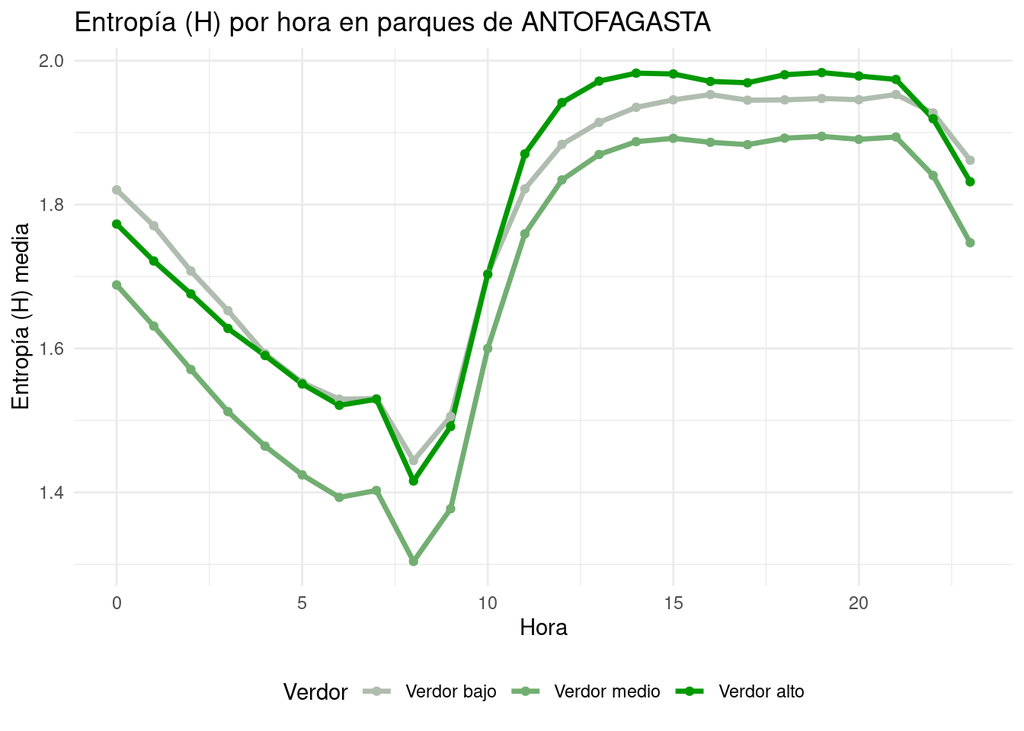

```r
ggplot(t1, aes(x = hour, y = mean_H, color = Verdor))+
  geom_line(linewidth=1.2)+
  geom_point() +
  scale_color_manual(values=c("#AFBDAF" , "#72AE72", "#009900"))+
  xlab("Hora")+
  ylab("Entropía (H) media")+
  theme_minimal()+
  theme(legend.position = "bottom")+
    ggtitle("Entropía (H) por hora en parques de ANTOFAGASTA")
```

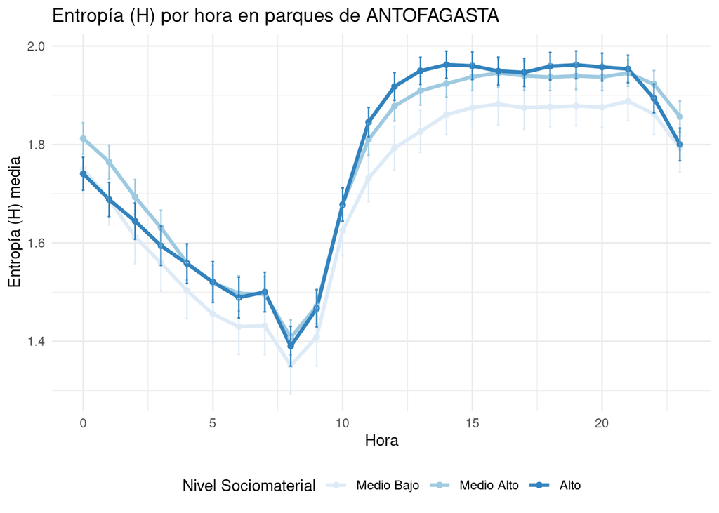

```r
#ggplot(data=t2[which(t2$Q %in% c("Medio Bajo","Alto")),], aes(x = hour, y = mean_H, color = Q))+
ggplot(data=t2, aes(x = hour, y = mean_H, color = Q))+
  geom_line(linewidth=1.2)+
  geom_point() +
  geom_errorbar(aes(ymin=mean_H-se,ymax=mean_H+se), width=.1)+
    scale_color_brewer()+
  xlab("Hora")+
  ylab("Entropía (H) media")+
    labs(color="Nivel Sociomaterial")+
  theme_minimal()+
  theme(legend.position = "bottom")+
    ggtitle("Entropía (H) por hora en parques de ANTOFAGASTA")
```

Se observa respecto al VERDOR:

1. Los parques de VERDOR ALTO son los que presentan más entropía en las horas laborales
2. Los parques de VERDOR MEDIO presentan la menor entropía a lo largo del día
3. Los parques de VERDOR BAJO presentan ligeramente mayor entropía durante las horas de descanso (22pm-5am)

Se observa respecto al CUARTIL SOCIOECONÓMICO (SEC):

4. Los parques de BAJO NIVEL SEC (Q2) presentan la menor entropía a lo largo del día
5. Los parques de MEDIO NIVEL SEC (Q3) presentan la mayor entropía durante las horas de descanso (22pm-5am)
6. Los parques de ALTO NIVEL SEC (Q4) presentan LIGERAMENTE la mayor entropía durante horario laboral (10pm-20pm)

# SANKEY

Visualización y análisis de flujo entre *verdor* y SEC

## 5. Primero extraemos las categorías para cada parque (porque no varían por H)

```r
valores<-antofa%>%
  mutate(Q=cut(ismt, breaks=c(0, 0.166461, 0.527227, 0.630018, 1),
                      labels=c("Bajo","Medio Bajo","Medio Alto","Alto"))) |>
  select(ID, Verdor, Q) |>
  distinct()

st_geometry(valores) <- NULL
```

## 6. Ahora la entropía (H) media en 3 rangos horarios: 6-8am, 12-2pm, 8-10pm

## 6.1 Primero extraemos las horas que nos interesan

```r
am<-filter(antofa, hour == 6 | hour == 7 | hour == 8)
md<-filter(antofa, hour == 12 | hour == 13 | hour == 14)
pm<-filter(antofa, hour == 20 | hour == 21 | hour == 22)
```

## 6.2 H promedio para la MAÑANA (6-8 AM)

```r
am_H<-am%>%
  group_by(ID) |>
  summarise(mean_H = mean(H))
```

## 6.3 H promedio para el MEDIO DIA (12-2 PM)

```r
md_H<-md%>%
  group_by(ID) |>
  summarise(mean_H = mean(H))
```

## 6.4 H promedio para la NOCHE (8-10 PM)

```r
pm_H<-pm%>%
  group_by(ID) |>
  summarise(mean_H = mean(H))
```

## 6.5 Unimos cada mean_H a sus valores

```r
am_valores <- merge(am_H, valores, by = "ID", left=TRUE)

md_valores <- merge(md_H, valores, by = "ID", left=TRUE)

pm_valores <- merge(pm_H, valores, by = "ID", left=TRUE)
```

## 7. Categorizamos la entropía

AM

```r
TercilesH <- function(x) {
 cut(x, breaks=c(quantile(am_valores$mean_H, probs = seq(0, 1, 1/3))),
    labels=c("Baja H","Media H","Alta H"), include.lowest=TRUE)
}

am_valores$H_cat=sapply(am_valores$mean_H, TercilesH)
```

MD

```r
TercilesH <- function(x) {
 cut(x, breaks=c(quantile(md_valores$mean_H, probs = seq(0, 1, 1/3))),
    labels=c("Baja H","Media H","Alta H"), include.lowest=TRUE)
}

md_valores$H_cat=sapply(md_valores$mean_H, TercilesH)
```

PM

```r
TercilesH <- function(x) {
 cut(x, breaks=c(quantile(pm_valores$mean_H, probs = seq(0, 1, 1/3))),
    labels=c("Baja H","Media H","Alta H"), include.lowest=TRUE)
}

pm_valores$H_cat=sapply(pm_valores$mean_H, TercilesH)
```

## 8. Graficamos mediante SANKEY

## 8.1 SANKEY Verdor - Q

parece que con hcharts no se puede :(

```r
# OBSOLETO
Verdor_Q<-am_valores%>%
  dplyr::select(Verdor, Q)

st_geometry(Verdor_Q) <- NULL

hchart(data_to_sankey(Verdor_Q), "sankey",
       hcaes(from=from, to=to, weight=weight),
       nodes = list(list(id = 'Verdor alto', color = "#009900"),
                    list(id = 'Verdor medio', color = "#72AE72"),
                    list(id = 'Verdor bajo', color = '#AFBDAF'),
                    list(id = 'Alto', color = "lightblue"),
                    list(id = 'Medio Alto', color = "blue"),
                    list(id = 'Medio Bajo', color = "darkblue")))
```

[interactive chart not shown]

Probemos con NETWORKD3

```r
library(networkD3)
```

CONNECTION DATAFRAME

```r
vbb<-sum(valores$Verdor == "Verdor bajo" & valores$Q == "Bajo", na.rm=T)
vbmb<-sum(valores$Verdor == "Verdor bajo" & valores$Q == "Medio Bajo", na.rm=T )
vbma<-sum(valores$Verdor == "Verdor bajo" & valores$Q == "Medio Alto", na.rm=T )
vba<-sum(valores$Verdor == "Verdor bajo" & valores$Q == "Alto" , na.rm=T)

vmb<-sum(valores$Verdor == "Verdor medio" & valores$Q == "Bajo",na.rm=T )
vmmb<-sum(valores$Verdor == "Verdor medio" & valores$Q == "Medio Bajo" , na.rm=T)
vmma<-sum(valores$Verdor == "Verdor medio" & valores$Q == "Medio Alto" , na.rm=T)
vma<-sum(valores$Verdor == "Verdor medio" & valores$Q == "Alto" , na.rm=T)

vab<-sum(valores$Verdor == "Verdor alto" & valores$Q == "Bajo",na.rm=T )
vamb<-sum(valores$Verdor == "Verdor alto" & valores$Q == "Medio Bajo", na.rm=T )
vama<-sum(valores$Verdor == "Verdor alto" & valores$Q == "Medio Alto", na.rm=T )
vaa<-sum(valores$Verdor == "Verdor alto" & valores$Q == "Alto", na.rm=T )

links <- data.frame(
  source=c("Verdor Bajo","Verdor Bajo", "Verdor Bajo", "Verdor Bajo",
           "Verdor Medio", "Verdor Medio", "Verdor Medio", "Verdor Medio",
           "Verdor Alto", "Verdor Alto", "Verdor Alto", "Verdor Alto"),
  target=c("Bajo", "Medio Bajo", "Medio Alto", "Alto",
           "Bajo", "Medio Bajo", "Medio Alto", "Alto",
           "Bajo", "Medio Bajo", "Medio Alto", "Alto"),
  value=c(vbb,vbmb,vbma,vba,
          vmb,vmmb,vmma,vma,
          vab,vamb,vama,vaa)
  )
```

CREAMOS NODOS Y LINKS

```r
nodes <- data.frame(
  name=c(as.character(links$source),
  as.character(links$target)) %>% unique()
)

links$IDsource <- match(links$source, nodes$name)-1
links$IDtarget <- match(links$target, nodes$name)-1
```

### PLOTEAMOS

En un gráfico de tipo Sankey, vemos a la izquierda los parques agrupados por verdor y a la derecha, los parques agrupados según el entorno SEC en que se encuentran. Las lineas muestran la coincidencia del verdor del parque y la categorización SEC del emplazamiento del parque.

```r
color_scale <- data.frame(
  range = c("#AFBDAF","#72AE72","#009900","#787F8F","#5C688A","#364C8A","#072A8C"),
  domain = c("Verdor Bajo", "Verdor Medio", "Verdor Alto", "Bajo", "Medio Bajo", "Medio Alto", "Alto"),
  stringsAsFactors = FALSE
)

p <- sankeyNetwork(Links = links, Nodes = nodes,
              Source = "IDsource", Target = "IDtarget",
              Value = "value", NodeID = "name", fontSize = 12, nodeWidth = 75, fontFamily = "Calibri",
              colourScale = JS(
                sprintf(
                'd3.scaleOrdinal()
                .domain(%s)
                .range(%s)',
                jsonlite::toJSON(color_scale$domain),
                jsonlite::toJSON(color_scale$range)
                )
              ),
            )
p
```

[interactive chart not shown]

De los 75 (100%) parque con mayor *verdor*, solo 4 y 5 se encuentran en sectores tipo *Medios Bajo* y *Medios Alto* respectivamente, (i.e. 5.3% y 6.6%). El grueso de los parques de mayor *verdor* tienen emplazamientos en barrios de nivel SEC tipo *Alto* (i.e. 88%).

REVISAR COLORES!

## 9. DENDROGRAMAS

```r
library(BBmisc)
```

HACER MATRIZ

```r
exp <- antofa |>
  select(c(1,2,12)) |>
  st_drop_geometry() |>
  drop_na()
#exp<-st_set_geometry(exp, NULL)

ids<-exp%>%
  select(c(1)) |>
  distinct()

entropias<-exp%>%
  select(c(3))
matriz<-matrix(entropias, nrow=185,ncol=24, byrow=TRUE)
```

REVISAR ESTO, NO SE SI FUNCIONA, NO ME DA LA CANTIDAD CORRECTA DE FILAS???? PERO ES UNA MATRIZ DEMASIADO GRANDE, ENTONCES NO SE REALMENTE SI ESTÁ CORRECTO, Y TAMPOCO SE VISUALIZARLAS

PARA HACER EL DENDROGRAMA, NECESITO UNA MATRIZ CON LOS DATOS ORDENADOS DE LA SIGUIENTE FORMA:

- CADA FILA DEBE SER UN PARQUE (DE SER POSIBLE, EN VEZ DEL N° DE FILA USAR EL ID)
- CADA VALOR HACIA LA DERECHA DEBE SER LA ENTROPÍA (H) DE CADA HORA

### Preparar datos para Dendrograma

```r
dend <- exp |>
  drop_na("hour") |>
  tidyr::pivot_wider(names_from = "hour",  values_from = "H") |>
  as.data.frame()
rownames(dend) <- dend$ID

dend <- dend |>
  select(-c("ID")) |>
  as.matrix() #|>
  # matrix(as.numeric(unlist()),nrow=nrow())

d <- matrix(as.numeric(unlist(dend)),nrow=nrow(dend))
```

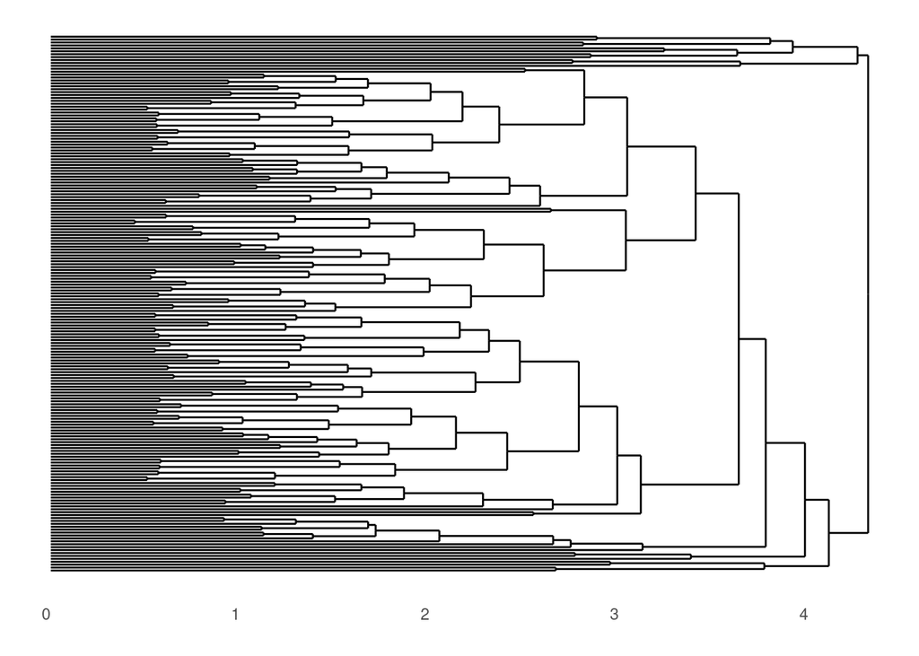

```r
dendro <- as.dendrogram(hclust(dist(d)))

library(ggdendro)
ggdendrogram(data = dendro, rotate = TRUE)
```